# Identified problems, business values, and the importance of the problems.

- Background of the company:  
  H & M is a multinational clothing company that was founded in 1947. H&M currently has approximately 4,850 stores and 53 online marketplaces. The company's online stores offer a wide range of products for customers to look through. However, too many options may make it difficult for customers to find what they are interested in or are looking for, which may prevent them from making a purchase. Because of these concerns, our team have identified the problem below and come up with a solution to help improve and solve these problems.
- Identified problem:  
  Problem is to predict what articles each customer will purchase in the 7-day period immediately after the training data ends.
- Business values and importance of the problem:  
  Enhancing the shopping experience  
  Boost product recommendations  
  Help customers make the right purchase choices → reduce returns → positive implications for sustainability

# Data Description

We were given the purchase history of customers across time. Below are the four data files we are going to use for this project:

- articles.csv:  
  detailed metadata for each article_id purchased
- customers.csv:  
  metadata for each customer_id in dataset
- transactions_train.csv: the training data, consisting of the purchases each customer for each date, and additional information
- Images:  
  a folder of images corresponding to each article_id, images are placed in subfolders, starting with the first three digits of the article_id; not all article_id values have a corresponding image.

# Upload Data and Exploring Data

```python
# Mounting Google Drive
from google.colab import drive
drive.mount('/content/drive')
```

```python
# Import libraries
import pandas as pd
import numpy as np
import seaborn as sns
import random
from sklearn.model_selection import train_test_split
from sklearn.metrics import pairwise_distances
from scipy.sparse import csr_matrix
from sklearn.metrics import mean_squared_error
from sklearn.metrics import mean_absolute_error
from sklearn import preprocessing
from matplotlib import pyplot as plt
from sklearn import tree
from sklearn.tree import DecisionTreeClassifier
from sklearn.metrics import plot_confusion_matrix
from sklearn.metrics import classification_report

from sklearn import preprocessing
from sklearn.metrics import confusion_matrix
from sklearn.preprocessing import StandardScaler

import torch
import torch.nn as nn
import torch.optim as optim
from itertools import chain

import os
from tqdm import tqdm
import matplotlib.pyplot as plt
import seaborn as sns
from wordcloud import WordCloud, STOPWORDS
from datetime import datetime
from PIL import Image
```

## Customer Data

```python
# Read data (with assignment operator)
cus = pd.read_csv('/content/drive/MyDrive/IS 695/IS699_Project/customers.csv')

cus
```

|  | customer_id | FN | Active | club_member_status | fashion_news_frequency | age | postal_code |
| --- | --- | --- | --- | --- | --- | --- | --- |
| 0 | 00000dbacae5abe5e23885899a1fa44253a17956c6d1c3... | NaN | NaN | ACTIVE | NONE | 49.0 | 52043ee2162cf5aa7ee79974281641c6f11a68d276429a... |
| 1 | 0000423b00ade91418cceaf3b26c6af3dd342b51fd051e... | NaN | NaN | ACTIVE | NONE | 25.0 | 2973abc54daa8a5f8ccfe9362140c63247c5eee03f1d93... |
| 2 | 000058a12d5b43e67d225668fa1f8d618c13dc232df0ca... | NaN | NaN | ACTIVE | NONE | 24.0 | 64f17e6a330a85798e4998f62d0930d14db8db1c054af6... |
| 3 | 00005ca1c9ed5f5146b52ac8639a40ca9d57aeff4d1bd2... | NaN | NaN | ACTIVE | NONE | 54.0 | 5d36574f52495e81f019b680c843c443bd343d5ca5b1c2... |
| 4 | 00006413d8573cd20ed7128e53b7b13819fe5cfc2d801f... | 1.0 | 1.0 | ACTIVE | Regularly | 52.0 | 25fa5ddee9aac01b35208d01736e57942317d756b32ddd... |
| ... | ... | ... | ... | ... | ... | ... | ... |
| 1371975 | ffffbbf78b6eaac697a8a5dfbfd2bfa8113ee5b403e474... | NaN | NaN | ACTIVE | NONE | 24.0 | 7aa399f7e669990daba2d92c577b52237380662f36480b... |
| 1371976 | ffffcd5046a6143d29a04fb8c424ce494a76e5cdf4fab5... | NaN | NaN | ACTIVE | NONE | 21.0 | 3f47f1279beb72215f4de557d950e0bfa73789d24acb5e... |
| 1371977 | ffffcf35913a0bee60e8741cb2b4e78b8a98ee5ff2e6a1... | 1.0 | 1.0 | ACTIVE | Regularly | 21.0 | 4563fc79215672cd6a863f2b4bf56b8f898f2d96ed590e... |
| 1371978 | ffffd7744cebcf3aca44ae7049d2a94b87074c3d4ffe38... | 1.0 | 1.0 | ACTIVE | Regularly | 18.0 | 8892c18e9bc3dca6aa4000cb8094fc4b51ee8db2ed14d7... |
| 1371979 | ffffd9ac14e89946416d80e791d064701994755c3ab686... | NaN | NaN | PRE-CREATE | NONE | 65.0 | 0a1a03306fb2f62164c2a439b38c0caa64b40deaae8687... |

1371980 rows × 7 columns

```python
cus.shape
```

```
(1371980, 7)
```

```python
cus.dtypes
```

```
customer_id                object
FN                        float64
Active                    float64
club_member_status         object
fashion_news_frequency     object
age                       float64
postal_code                object
dtype: object
```

```python
#Checking null value
cus.isnull().sum()
```

```
customer_id                    0
FN                        895050
Active                    907576
club_member_status          6062
fashion_news_frequency     16009
age                        15861
postal_code                    0
dtype: int64
```

```python
#Change the value in fashion news frequency column
cus['fashion_news_frequency']=cus['fashion_news_frequency'].replace(['None'],'NONE')
```

### Exploring Data

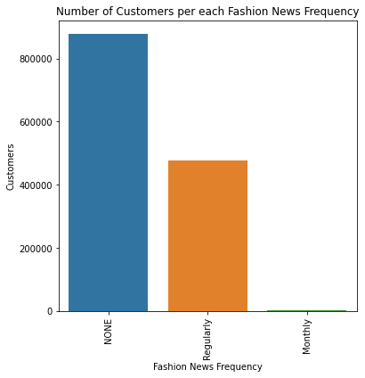

```python
#Exploring about fashion news frequency column
temp = cus.groupby(["fashion_news_frequency"])["customer_id"].count()
df = pd.DataFrame({'Fashion News Frequency': temp.index,
                   'Customers': temp.values
                  })
df = df.sort_values(['Customers'], ascending=False)
plt.figure(figsize = (6,6))
plt.title(f'Number of Customers per each Fashion News Frequency')
sns.set_color_codes("pastel")
s = sns.barplot(x = 'Fashion News Frequency', y="Customers", data=df)
s.set_xticklabels(s.get_xticklabels(),rotation=90)
locs, labels = plt.xticks()
plt.show()
```

```python
cus['fashion_news_frequency'].value_counts()
```

```
NONE         877713
Regularly    477416
Monthly         842
Name: fashion_news_frequency, dtype: int64
```

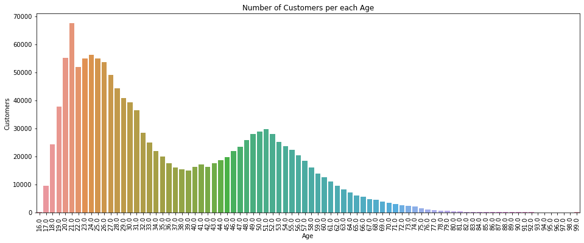

```python
#Exploring age column
temp = cus.groupby(["age"])["customer_id"].count()
df = pd.DataFrame({'Age': temp.index,
                   'Customers': temp.values
                  })
df = df.sort_values(['Age'], ascending=False)
plt.figure(figsize = (16,6))
plt.title(f'Number of Customers per each Age')
sns.set_color_codes("pastel")
s = sns.barplot(x = 'Age', y="Customers", data=df)
s.set_xticklabels(s.get_xticklabels(),rotation=90)
locs, labels = plt.xticks()
plt.show()
```

H & M has the majority of customers with the age range from 18 to 31 years old.

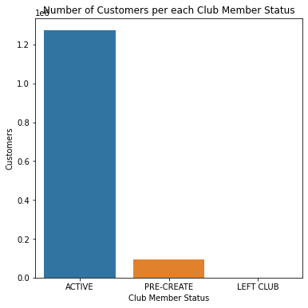

```python
#Exploring the Club Member Status
temp = cus.groupby(["club_member_status"])["customer_id"].count()
df = pd.DataFrame({'Club Member Status': temp.index,
                   'Customers': temp.values
                  })
df = df.sort_values(['Customers'], ascending=False)
plt.figure(figsize = (6,6))
plt.title(f'Number of Customers per each Club Member Status')
sns.set_color_codes("pastel")
s = sns.barplot(x = 'Club Member Status', y="Customers", data=df)
s.set_xticklabels(s.get_xticklabels(),rotation=0)
locs, labels = plt.xticks()
plt.show()
```

Most customers are Active Member

About more than 90,000 customers are pre-create member

Very few customers left the club

```python
cus['club_member_status'].value_counts()
```

```
ACTIVE        1272491
PRE-CREATE      92960
LEFT CLUB         467
Name: club_member_status, dtype: int64
```

## Article Data

```python
# Read data (with assignment operator)
art = pd.read_csv('/content/drive/MyDrive/IS 695/IS699_Project/articles.csv')
art
```

|  | article_id | product_code | prod_name | product_type_no | product_type_name | product_group_name | graphical_appearance_no | graphical_appearance_name | colour_group_code | colour_group_name | ... | department_name | index_code | index_name | index_group_no | index_group_name | section_no | section_name | garment_group_no | garment_group_name | detail_desc |
| --- | --- | --- | --- | --- | --- | --- | --- | --- | --- | --- | --- | --- | --- | --- | --- | --- | --- | --- | --- | --- | --- |
| 0 | 108775015 | 108775 | Strap top | 253 | Vest top | Garment Upper body | 1010016 | Solid | 9 | Black | ... | Jersey Basic | A | Ladieswear | 1 | Ladieswear | 16 | Womens Everyday Basics | 1002 | Jersey Basic | Jersey top with narrow shoulder straps. |
| 1 | 108775044 | 108775 | Strap top | 253 | Vest top | Garment Upper body | 1010016 | Solid | 10 | White | ... | Jersey Basic | A | Ladieswear | 1 | Ladieswear | 16 | Womens Everyday Basics | 1002 | Jersey Basic | Jersey top with narrow shoulder straps. |
| 2 | 108775051 | 108775 | Strap top (1) | 253 | Vest top | Garment Upper body | 1010017 | Stripe | 11 | Off White | ... | Jersey Basic | A | Ladieswear | 1 | Ladieswear | 16 | Womens Everyday Basics | 1002 | Jersey Basic | Jersey top with narrow shoulder straps. |
| 3 | 110065001 | 110065 | OP T-shirt (Idro) | 306 | Bra | Underwear | 1010016 | Solid | 9 | Black | ... | Clean Lingerie | B | Lingeries/Tights | 1 | Ladieswear | 61 | Womens Lingerie | 1017 | Under-, Nightwear | Microfibre T-shirt bra with underwired, moulde... |
| 4 | 110065002 | 110065 | OP T-shirt (Idro) | 306 | Bra | Underwear | 1010016 | Solid | 10 | White | ... | Clean Lingerie | B | Lingeries/Tights | 1 | Ladieswear | 61 | Womens Lingerie | 1017 | Under-, Nightwear | Microfibre T-shirt bra with underwired, moulde... |
| ... | ... | ... | ... | ... | ... | ... | ... | ... | ... | ... | ... | ... | ... | ... | ... | ... | ... | ... | ... | ... | ... |
| 105537 | 953450001 | 953450 | 5pk regular Placement1 | 302 | Socks | Socks & Tights | 1010014 | Placement print | 9 | Black | ... | Socks Bin | F | Menswear | 3 | Menswear | 26 | Men Underwear | 1021 | Socks and Tights | Socks in a fine-knit cotton blend with a small... |
| 105538 | 953763001 | 953763 | SPORT Malaga tank | 253 | Vest top | Garment Upper body | 1010016 | Solid | 9 | Black | ... | Jersey | A | Ladieswear | 1 | Ladieswear | 2 | H&M+ | 1005 | Jersey Fancy | Loose-fitting sports vest top in ribbed fast-d... |
| 105539 | 956217002 | 956217 | Cartwheel dress | 265 | Dress | Garment Full body | 1010016 | Solid | 9 | Black | ... | Jersey | A | Ladieswear | 1 | Ladieswear | 18 | Womens Trend | 1005 | Jersey Fancy | Short, A-line dress in jersey with a round nec... |
| 105540 | 957375001 | 957375 | CLAIRE HAIR CLAW | 72 | Hair clip | Accessories | 1010016 | Solid | 9 | Black | ... | Small Accessories | D | Divided | 2 | Divided | 52 | Divided Accessories | 1019 | Accessories | Large plastic hair claw. |
| 105541 | 959461001 | 959461 | Lounge dress | 265 | Dress | Garment Full body | 1010016 | Solid | 11 | Off White | ... | Jersey | A | Ladieswear | 1 | Ladieswear | 18 | Womens Trend | 1005 | Jersey Fancy | Calf-length dress in ribbed jersey made from a... |

105542 rows × 25 columns

```python
#Drop unused columns
art=art.drop(columns=['product_code','product_type_no','graphical_appearance_no','colour_group_code','perceived_colour_value_id','perceived_colour_master_id','department_no','index_code','index_group_no','section_no','garment_group_no','detail_desc'],axis=1)
art
```

|  | article_id | prod_name | product_type_name | product_group_name | graphical_appearance_name | colour_group_name | perceived_colour_value_name | perceived_colour_master_name | department_name | index_name | index_group_name | section_name | garment_group_name |
| --- | --- | --- | --- | --- | --- | --- | --- | --- | --- | --- | --- | --- | --- |
| 0 | 108775015 | Strap top | Vest top | Garment Upper body | Solid | Black | Dark | Black | Jersey Basic | Ladieswear | Ladieswear | Womens Everyday Basics | Jersey Basic |
| 1 | 108775044 | Strap top | Vest top | Garment Upper body | Solid | White | Light | White | Jersey Basic | Ladieswear | Ladieswear | Womens Everyday Basics | Jersey Basic |
| 2 | 108775051 | Strap top (1) | Vest top | Garment Upper body | Stripe | Off White | Dusty Light | White | Jersey Basic | Ladieswear | Ladieswear | Womens Everyday Basics | Jersey Basic |
| 3 | 110065001 | OP T-shirt (Idro) | Bra | Underwear | Solid | Black | Dark | Black | Clean Lingerie | Lingeries/Tights | Ladieswear | Womens Lingerie | Under-, Nightwear |
| 4 | 110065002 | OP T-shirt (Idro) | Bra | Underwear | Solid | White | Light | White | Clean Lingerie | Lingeries/Tights | Ladieswear | Womens Lingerie | Under-, Nightwear |
| ... | ... | ... | ... | ... | ... | ... | ... | ... | ... | ... | ... | ... | ... |
| 105537 | 953450001 | 5pk regular Placement1 | Socks | Socks & Tights | Placement print | Black | Dark | Black | Socks Bin | Menswear | Menswear | Men Underwear | Socks and Tights |
| 105538 | 953763001 | SPORT Malaga tank | Vest top | Garment Upper body | Solid | Black | Dark | Black | Jersey | Ladieswear | Ladieswear | H&M+ | Jersey Fancy |
| 105539 | 956217002 | Cartwheel dress | Dress | Garment Full body | Solid | Black | Dark | Black | Jersey | Ladieswear | Ladieswear | Womens Trend | Jersey Fancy |
| 105540 | 957375001 | CLAIRE HAIR CLAW | Hair clip | Accessories | Solid | Black | Dark | Black | Small Accessories | Divided | Divided | Divided Accessories | Accessories |
| 105541 | 959461001 | Lounge dress | Dress | Garment Full body | Solid | Off White | Dusty Light | White | Jersey | Ladieswear | Ladieswear | Womens Trend | Jersey Fancy |

105542 rows × 13 columns

```python
art.shape
```

```
(105542, 13)
```

```python
art.dtypes
```

```
article_id                       int64
prod_name                       object
product_type_name               object
product_group_name              object
graphical_appearance_name       object
colour_group_name               object
perceived_colour_value_name     object
perceived_colour_master_name    object
department_name                 object
index_name                      object
index_group_name                object
section_name                    object
garment_group_name              object
dtype: object
```

```python
art.isnull().sum()
```

```
article_id                      0
prod_name                       0
product_type_name               0
product_group_name              0
graphical_appearance_name       0
colour_group_name               0
perceived_colour_value_name     0
perceived_colour_master_name    0
department_name                 0
index_name                      0
index_group_name                0
section_name                    0
garment_group_name              0
dtype: int64
```

### Exploring Data

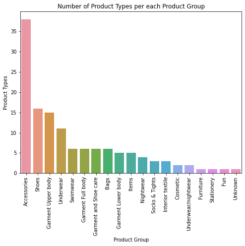

```python
temp = art.groupby(["product_group_name"])["product_type_name"].nunique()
df = pd.DataFrame({'Product Group': temp.index,
                   'Product Types': temp.values
                  })
df = df.sort_values(['Product Types'], ascending=False)
plt.figure(figsize = (8,6))
plt.title('Number of Product Types per each Product Group')
sns.set_color_codes("pastel")
s = sns.barplot(x = 'Product Group', y="Product Types", data=df)
s.set_xticklabels(s.get_xticklabels(),rotation=90)
locs, labels = plt.xticks()
plt.show()
```

From the "Number of Product Types per each Product Group" bar graph above, we can identify the top 3 product group that has product type:  
Accessories  
Shoes  
Garment Upper Body

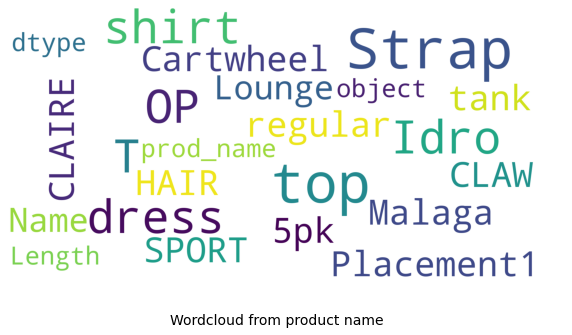

```python
stopwords = set(STOPWORDS)

def show_wordcloud(data, title = None):
    wordcloud = WordCloud(
        background_color='white',
        stopwords=stopwords,
        max_words=200,
        max_font_size=40,
        scale=5,
        random_state=1
    ).generate(str(data))

    fig = plt.figure(1, figsize=(10,10))
    plt.axis('off')
    if title:
        fig.suptitle(title, fontsize=14)
        fig.subplots_adjust(top=2.3)

    plt.imshow(wordcloud)
    plt.show()
show_wordcloud(art["prod_name"], "Wordcloud from product name")
```

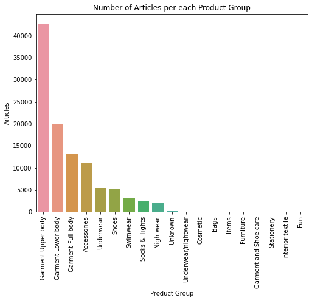

```python
temp = art.groupby(["product_group_name"])["article_id"].nunique()
df = pd.DataFrame({'Product Group': temp.index,
                   'Articles': temp.values
                  })
df = df.sort_values(['Articles'], ascending=False)
plt.figure(figsize = (8,6))
plt.title('Number of Articles per each Product Group')
sns.set_color_codes("pastel")
s = sns.barplot(x = 'Product Group', y="Articles", data=df)
s.set_xticklabels(s.get_xticklabels(),rotation=90)
locs, labels = plt.xticks()
plt.show()
```

From the graph above, we can see that Garment Upper Body is the product group that include the most articles.

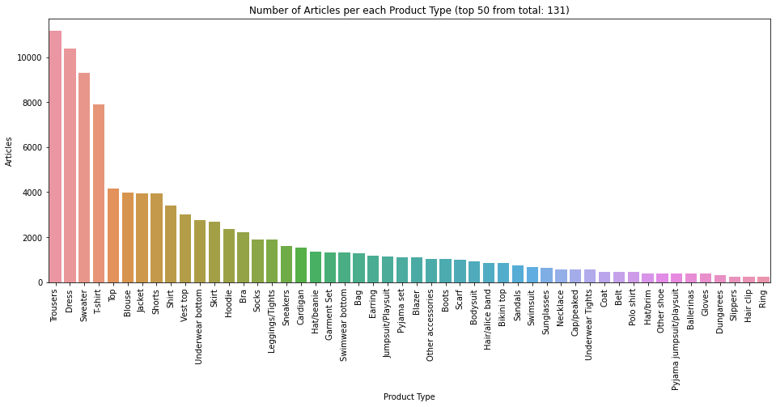

```python
temp = art.groupby(["product_type_name"])["article_id"].nunique()
df = pd.DataFrame({'Product Type': temp.index,
                   'Articles': temp.values
                  })
total_types = len(df['Product Type'].unique())
df = df.sort_values(['Articles'], ascending=False)[0:50]
plt.figure(figsize = (16,6))
plt.title(f'Number of Articles per each Product Type (top 50 from total: {total_types})')
sns.set_color_codes("pastel")
s = sns.barplot(x = 'Product Type', y="Articles", data=df)
s.set_xticklabels(s.get_xticklabels(),rotation=90)
locs, labels = plt.xticks()
plt.show()
```

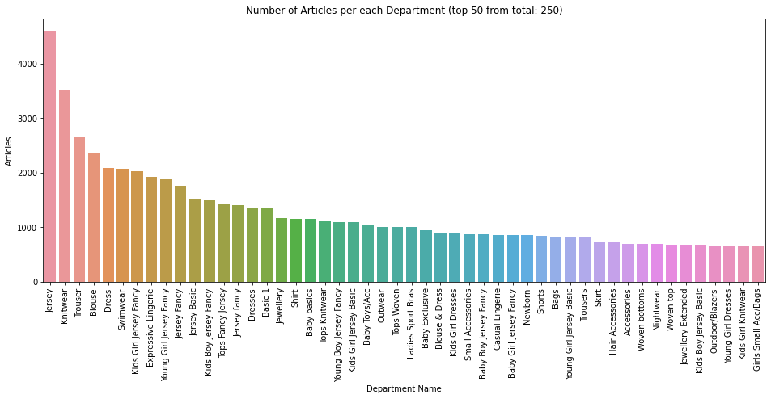

```python
temp = art.groupby(["department_name"])["article_id"].nunique()
df = pd.DataFrame({'Department Name': temp.index,
                   'Articles': temp.values
                  })
total_depts = len(df['Department Name'].unique())
df = df.sort_values(['Articles'], ascending=False).head(50)
plt.figure(figsize = (16,6))
plt.title(f'Number of Articles per each Department (top 50 from total: {total_depts})')
sns.set_color_codes("pastel")
s = sns.barplot(x = 'Department Name', y="Articles", data=df)
s.set_xticklabels(s.get_xticklabels(),rotation=90)
locs, labels = plt.xticks()
plt.show()
```

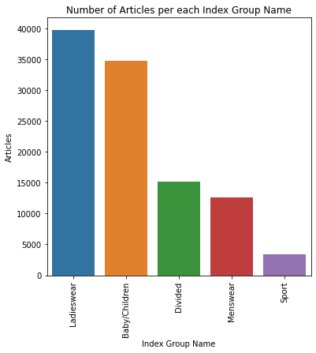

```python
temp = art.groupby(["index_group_name"])["article_id"].nunique()
df = pd.DataFrame({'Index Group Name': temp.index,
                   'Articles': temp.values
                  })
df = df.sort_values(['Articles'], ascending=False)
plt.figure(figsize = (6,6))
plt.title(f'Number of Articles per each Index Group Name')
sns.set_color_codes("pastel")
s = sns.barplot(x = 'Index Group Name', y="Articles", data=df)
s.set_xticklabels(s.get_xticklabels(),rotation=90)
locs, labels = plt.xticks()
plt.show()
```

Based on the bar graph above, we discover that:

- Ladieswear is the group that has highest number of articles
- Sport is the group that has lowest number of articles

## Transaction Data

```python
# Read data (with assignment operator)
transaction = pd.read_csv('/content/drive/MyDrive/IS 695/IS699_Project/transactions_train.csv')

transaction
```

|  | t_dat | customer_id | article_id | price | sales_channel_id |
| --- | --- | --- | --- | --- | --- |
| 0 | 2018-09-20 | 000058a12d5b43e67d225668fa1f8d618c13dc232df0ca... | 663713001 | 0.050831 | 2 |
| 1 | 2018-09-20 | 000058a12d5b43e67d225668fa1f8d618c13dc232df0ca... | 541518023 | 0.030492 | 2 |
| 2 | 2018-09-20 | 00007d2de826758b65a93dd24ce629ed66842531df6699... | 505221004 | 0.015237 | 2 |
| 3 | 2018-09-20 | 00007d2de826758b65a93dd24ce629ed66842531df6699... | 685687003 | 0.016932 | 2 |
| 4 | 2018-09-20 | 00007d2de826758b65a93dd24ce629ed66842531df6699... | 685687004 | 0.016932 | 2 |
| ... | ... | ... | ... | ... | ... |
| 31788319 | 2020-09-22 | fff2282977442e327b45d8c89afde25617d00124d0f999... | 929511001 | 0.059305 | 2 |
| 31788320 | 2020-09-22 | fff2282977442e327b45d8c89afde25617d00124d0f999... | 891322004 | 0.042356 | 2 |
| 31788321 | 2020-09-22 | fff380805474b287b05cb2a7507b9a013482f7dd0bce0e... | 918325001 | 0.043203 | 1 |
| 31788322 | 2020-09-22 | fff4d3a8b1f3b60af93e78c30a7cb4cf75edaf2590d3e5... | 833459002 | 0.006763 | 1 |
| 31788323 | 2020-09-22 | fffef3b6b73545df065b521e19f64bf6fe93bfd450ab20... | 898573003 | 0.033881 | 2 |

31788324 rows × 5 columns

```python
transaction.shape
```

```
(31788324, 5)
```

```python
transaction.dtypes
```

```
t_dat                object
customer_id          object
article_id            int64
price               float64
sales_channel_id      int64
dtype: object
```

```python
transaction.isnull().sum()
```

```
t_dat               0
customer_id         0
article_id          0
price               0
sales_channel_id    0
dtype: int64
```

### Exploring data

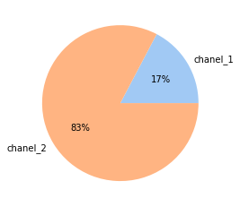

```python
df = transaction.sample(100_000)
chanel_1= df.loc[df["sales_channel_id"]==1].sales_channel_id.sum()
chanel_2= df.loc[df["sales_channel_id"]==2].sales_channel_id.sum()

data=[chanel_1,chanel_2]
labels=['chanel_1','chanel_2']

colors = sns.color_palette('pastel')[0:5]
plt.pie(data, labels = labels, colors = colors, autopct='%.0f%%')
plt.show()
```

[figure not shown]

```python
df = transaction.sample(100_000).groupby(["t_dat"])["article_id"].count().reset_index()
df["t_dat"] = df["t_dat"].apply(lambda x: datetime.strptime(x, '%Y-%m-%d'))
df.columns = ["Date", "Transactions"]
fig, ax = plt.subplots(1, 1, figsize=(16,6))
plt.plot(df["Date"], df["Transactions"], color="Darkgreen")
plt.xlabel("Date")
plt.ylabel("Transactions")
plt.title(f"Transactions per day (100k sample; to get the real volume, please consider that real transaction count is {round(transaction.shape[0]/10.e6,2)}M)")
plt.show()
```

We can see the increase in sales in October, December and April-May (Holidays promotion).

|  | article_id | prod_name | product_type_name | product_group_name | graphical_appearance_name | colour_group_name | perceived_colour_value_name | perceived_colour_master_name | department_name | index_name | index_group_name | section_name | garment_group_name |
| --- | --- | --- | --- | --- | --- | --- | --- | --- | --- | --- | --- | --- | --- |
| 53892 | 706016001 | Jade HW Skinny Denim TRS | Trousers | Garment Lower body | Solid | Black | Dark | Black | Trousers | Divided | Divided | Divided Collection | Trousers |

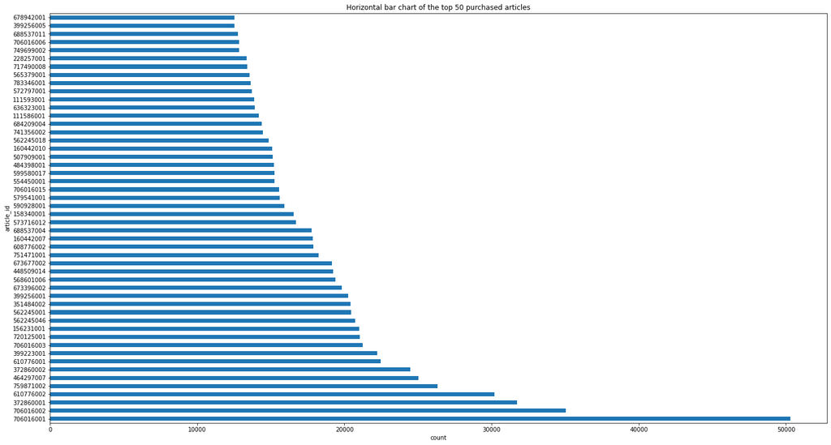

```python
# Top 50 articles that were purchased the most
plt.figure(figsize = (24,13))
transaction['article_id'].value_counts()[:50].plot(kind='barh')
plt.title('Horizontal bar chart of the top 50 purchased articles')
plt.xlabel('count')
plt.ylabel('article_id')

#Display details of the top article that were purchased the most
art.loc[art['article_id'] == 706016001]
```

The bar chart above shows the 50 articles that were purchased the most. Using th article id, we figure out that the product was purchased the most is Jade HW Skinny Denim TRS which belong to the Trousers department.

## Image Data

```python
import cv2, matplotlib.pyplot as plt
from os.path import exists
```

```python
#number of each article_id in the transaction table
vc = transaction['article_id'].value_counts()
pairs = {}
for j,i in enumerate(vc.index.values[1000:1032]):#for any article that has 1000-1032 items
    #if j%10==0: print(j,', ',end='')
    #identify the customers that bought the article
    USERS = transaction.loc[transaction.article_id==i.item(),'customer_id'].unique()
    #Identify the articles that those customers above also bought
    vc2 = transaction.loc[(transaction.customer_id.isin(USERS))&(transaction.article_id!=i.item()),'article_id'].value_counts()
    #print the top three items that they also bought with the article
    pairs[i.item()] = [vc2.index[0], vc2.index[1], vc2.index[2]]
```

```python
items=pd.read_csv('/content/drive/MyDrive/IS 695/IS699_Project/articles.csv')
BASE = '/content/drive/MyDrive/IS 695/IS699_Project/images/'

for i,(k,v) in enumerate(pairs.items()):
    name1 = BASE+'0'+str(k)[:2]+'/0'+str(k)+'.jpg'
    name2 = BASE+'0'+str(v[0])[:2]+'/0'+str(v[0])+'.jpg'
    name3 = BASE+'0'+str(v[1])[:2]+'/0'+str(v[1])+'.jpg'
    name4 = BASE+'0'+str(v[2])[:2]+'/0'+str(v[2])+'.jpg'
    if exists(name1) & exists(name2) & exists(name3) & exists(name4):
        plt.figure(figsize=(20,5))
        img1 = cv2.imread(name1)[:,:,::-1]
        img2 = cv2.imread(name2)[:,:,::-1]
        img3 = cv2.imread(name3)[:,:,::-1]
        img4 = cv2.imread(name4)[:,:,::-1]
        plt.subplot(1,4,1)
        plt.title('When customers buy this',size=18)
        plt.imshow(img1)
        plt.subplot(1,4,2)
        plt.title('They buy this',size=18)
        plt.imshow(img2)
        plt.subplot(1,4,3)
        plt.title('They buy this',size=18)
        plt.imshow(img3)
        plt.subplot(1,4,4)
        plt.title('They buy this',size=18)
        plt.imshow(img4)
        plt.show()
```

[output not shown]

# Neural Collaborative Filtering

## Scale Down the Dataset

```python
#Check number of total purchase
total_purc=transaction.groupby('customer_id').count()
total_purc
```

| customer_id | t_dat | article_id | price | sales_channel_id |
| --- | --- | --- | --- | --- |
| 00000dbacae5abe5e23885899a1fa44253a17956c6d1c3d25f88aa139fdfc657 | 21 | 21 | 21 | 21 |
| 0000423b00ade91418cceaf3b26c6af3dd342b51fd051eec9c12fb36984420fa | 86 | 86 | 86 | 86 |
| 000058a12d5b43e67d225668fa1f8d618c13dc232df0cad8ffe7ad4a1091e318 | 18 | 18 | 18 | 18 |
| 00005ca1c9ed5f5146b52ac8639a40ca9d57aeff4d1bd2c5feb1ca5dff07c43e | 2 | 2 | 2 | 2 |
| 00006413d8573cd20ed7128e53b7b13819fe5cfc2d801fe7fc0f26dd8d65a85a | 13 | 13 | 13 | 13 |
| ... | ... | ... | ... | ... |
| ffffbbf78b6eaac697a8a5dfbfd2bfa8113ee5b403e4747568cac33e8c541831 | 51 | 51 | 51 | 51 |
| ffffcd5046a6143d29a04fb8c424ce494a76e5cdf4fab53481233731b5c4f8b7 | 84 | 84 | 84 | 84 |
| ffffcf35913a0bee60e8741cb2b4e78b8a98ee5ff2e6a1778d0116cffd259264 | 45 | 45 | 45 | 45 |
| ffffd7744cebcf3aca44ae7049d2a94b87074c3d4ffe38b2236865d949d4df6a | 7 | 7 | 7 | 7 |
| ffffd9ac14e89946416d80e791d064701994755c3ab686a1eaf3458c36f52241 | 1 | 1 | 1 | 1 |

1362281 rows × 4 columns

```python
#Combine the total purchase table with the transaction table
trans=pd.merge(transaction,total_purc,on='customer_id', how='inner')
trans
```

|  | t_dat_x | customer_id | article_id_x | price_x | sales_channel_id_x | t_dat_y | article_id_y | price_y | sales_channel_id_y |
| --- | --- | --- | --- | --- | --- | --- | --- | --- | --- |
| 0 | 2018-09-20 | 000058a12d5b43e67d225668fa1f8d618c13dc232df0ca... | 663713001 | 0.050831 | 2 | 18 | 18 | 18 | 18 |
| 1 | 2018-09-20 | 000058a12d5b43e67d225668fa1f8d618c13dc232df0ca... | 541518023 | 0.030492 | 2 | 18 | 18 | 18 | 18 |
| 2 | 2018-09-24 | 000058a12d5b43e67d225668fa1f8d618c13dc232df0ca... | 663713001 | 0.050831 | 2 | 18 | 18 | 18 | 18 |
| 3 | 2019-03-01 | 000058a12d5b43e67d225668fa1f8d618c13dc232df0ca... | 578020002 | 0.013542 | 2 | 18 | 18 | 18 | 18 |
| 4 | 2020-02-03 | 000058a12d5b43e67d225668fa1f8d618c13dc232df0ca... | 723529001 | 0.025407 | 2 | 18 | 18 | 18 | 18 |
| ... | ... | ... | ... | ... | ... | ... | ... | ... | ... |
| 31788319 | 2020-09-22 | fee56cc5315dafb35a4490ccc6f711092cae913550c832... | 903647001 | 0.050831 | 2 | 2 | 2 | 2 | 2 |
| 31788320 | 2020-09-22 | fee56cc5315dafb35a4490ccc6f711092cae913550c832... | 903647001 | 0.050831 | 2 | 2 | 2 | 2 | 2 |
| 31788321 | 2020-09-22 | ff5b8a8b26bf93a66290e9bd1b73393ac6a58968a78519... | 913597001 | 0.042356 | 2 | 3 | 3 | 3 | 3 |
| 31788322 | 2020-09-22 | ff5b8a8b26bf93a66290e9bd1b73393ac6a58968a78519... | 903420001 | 0.033881 | 2 | 3 | 3 | 3 | 3 |
| 31788323 | 2020-09-22 | ff5b8a8b26bf93a66290e9bd1b73393ac6a58968a78519... | 761406001 | 0.025407 | 2 | 3 | 3 | 3 | 3 |

31788324 rows × 9 columns

```python
#Drop the unused table and sort the customers by the total purchase
trans=trans.drop(columns=['price_x','sales_channel_id_x','t_dat_y','price_y','sales_channel_id_y'],axis=1)
trans=trans.rename(columns = {'article_id_y':'Total_Purchase'})
```

```python
transac=trans.sort_values(by='Total_Purchase',ascending=False)
transac['t_dat_x']= transac['t_dat_x'].astype('datetime64[ns]')
transac
```

|  | t_dat_x | customer_id | article_id_x | Total_Purchase |
| --- | --- | --- | --- | --- |
| 1673864 | 2019-06-11 | be1981ab818cf4ef6765b2ecaea7a2cbf14ccd6e8a7ee9... | 562245064 | 1895 |
| 1675137 | 2020-09-03 | be1981ab818cf4ef6765b2ecaea7a2cbf14ccd6e8a7ee9... | 898692003 | 1895 |
| 1675121 | 2020-08-29 | be1981ab818cf4ef6765b2ecaea7a2cbf14ccd6e8a7ee9... | 898703001 | 1895 |
| 1675122 | 2020-08-29 | be1981ab818cf4ef6765b2ecaea7a2cbf14ccd6e8a7ee9... | 833781002 | 1895 |
| 1675123 | 2020-08-29 | be1981ab818cf4ef6765b2ecaea7a2cbf14ccd6e8a7ee9... | 863646001 | 1895 |
| ... | ... | ... | ... | ... |
| 30471263 | 2020-01-30 | 3ee34051b58863c04ed92426c7c9b7b9d8ec7773c1f194... | 794007001 | 1 |
| 30035547 | 2019-11-29 | ef4662d4fa9f406497c69d47532e7deaf69f372cb1e7a2... | 748355002 | 1 |
| 31206292 | 2020-05-15 | 2ae44e13cdcd42c77f7d6c7984581123236256ac4529df... | 836327001 | 1 |
| 29345225 | 2019-09-15 | 2ea59d1ddf3ecee3c394868c72974a0972a3a6ee61b8a1... | 688537017 | 1 |
| 28981240 | 2019-08-06 | 9c278911119e9bc28676f9c06d81b45947d940392d3b12... | 738368004 | 1 |

31788324 rows × 4 columns

```python
#Part_trans will be the data we are looking on as it conists all the customers made >=330 transactions
part_trans= transac.loc[transac['Total_Purchase'] >= 300]
part_trans
```

|  | t_dat_x | customer_id | article_id_x | Total_Purchase |
| --- | --- | --- | --- | --- |
| 1673864 | 2019-06-11 | be1981ab818cf4ef6765b2ecaea7a2cbf14ccd6e8a7ee9... | 562245064 | 1895 |
| 1675137 | 2020-09-03 | be1981ab818cf4ef6765b2ecaea7a2cbf14ccd6e8a7ee9... | 898692003 | 1895 |
| 1675121 | 2020-08-29 | be1981ab818cf4ef6765b2ecaea7a2cbf14ccd6e8a7ee9... | 898703001 | 1895 |
| 1675122 | 2020-08-29 | be1981ab818cf4ef6765b2ecaea7a2cbf14ccd6e8a7ee9... | 833781002 | 1895 |
| 1675123 | 2020-08-29 | be1981ab818cf4ef6765b2ecaea7a2cbf14ccd6e8a7ee9... | 863646001 | 1895 |
| ... | ... | ... | ... | ... |
| 15110374 | 2020-05-29 | 5b39bd74e88202223df4bc09768859e1752146e3fef699... | 863001001 | 300 |
| 15110375 | 2020-05-29 | 5b39bd74e88202223df4bc09768859e1752146e3fef699... | 768759006 | 300 |
| 15110376 | 2020-05-29 | 5b39bd74e88202223df4bc09768859e1752146e3fef699... | 817416001 | 300 |
| 15110377 | 2020-05-29 | 5b39bd74e88202223df4bc09768859e1752146e3fef699... | 840360003 | 300 |
| 15110378 | 2020-06-20 | 5b39bd74e88202223df4bc09768859e1752146e3fef699... | 717490064 | 300 |

1336909 rows × 4 columns

```python
#Number of customer we will be working on
part_trans['customer_id'].nunique()
```

```
3292
```

```python
#Number of article we will be working on
part_trans['article_id_x'].nunique()
```

```
74972
```

## Data Preprocessing

```python
#Postivie Sampling (All the transactions is labeled as 1)
part_trans=part_trans.drop(columns=['Total_Purchase'], axis=1)
part_trans=part_trans.rename(columns={"article_id_x": "article_id"})
part_trans['Purchased']=1
```

```python
#Encoding customer_id and article_id
label_encoder = preprocessing.LabelEncoder()
part_trans['customer_id'] = label_encoder.fit_transform(part_trans['customer_id'])
part_trans['article_id'] = label_encoder.fit_transform(part_trans['article_id'])
part_trans
```

|  | t_dat_x | customer_id | article_id | Purchased |
| --- | --- | --- | --- | --- |
| 1673864 | 2019-06-11 | 2468 | 8227 | 1 |
| 1675137 | 2020-09-03 | 2468 | 72624 | 1 |
| 1675121 | 2020-08-29 | 2468 | 72631 | 1 |
| 1675122 | 2020-08-29 | 2468 | 63133 | 1 |
| 1675123 | 2020-08-29 | 2468 | 67835 | 1 |
| ... | ... | ... | ... | ... |
| 15110374 | 2020-05-29 | 1177 | 67713 | 1 |
| 15110375 | 2020-05-29 | 1177 | 50861 | 1 |
| 15110376 | 2020-05-29 | 1177 | 60339 | 1 |
| 15110377 | 2020-05-29 | 1177 | 64097 | 1 |
| 15110378 | 2020-06-20 | 1177 | 38855 | 1 |

1336909 rows × 4 columns

```python
# Sort data based on 'customer_id' and 'date'
part_transaction = part_trans.sort_values(by=['customer_id', 't_dat_x'])
part_transaction
```

|  | t_dat_x | customer_id | article_id | Purchased |
| --- | --- | --- | --- | --- |
| 7991066 | 2018-10-01 | 0 | 8395 | 1 |
| 7991065 | 2018-10-01 | 0 | 28860 | 1 |
| 7991070 | 2018-10-01 | 0 | 25943 | 1 |
| 7991069 | 2018-10-01 | 0 | 28089 | 1 |
| 7991068 | 2018-10-01 | 0 | 5682 | 1 |
| ... | ... | ... | ... | ... |
| 12739662 | 2020-09-21 | 3291 | 74178 | 1 |
| 12739663 | 2020-09-21 | 3291 | 74178 | 1 |
| 12739665 | 2020-09-21 | 3291 | 53266 | 1 |
| 12739666 | 2020-09-21 | 3291 | 27099 | 1 |
| 12739667 | 2020-09-21 | 3291 | 27099 | 1 |

1336909 rows × 4 columns

```python
# Partition the data
test_data = part_transaction.drop_duplicates(subset=["customer_id"], keep='last') #Drop all the data record for each users and keep the last record for training data
index_df = part_transaction.index.isin(test_data.index)
train_data = part_transaction.iloc[~index_df]
print(len(train_data), len(test_data))
```

```
1333617 3292
```

```python
# Remove the date column
train_data = train_data[['customer_id', 'article_id', 'Purchased']]
test_data = test_data[['customer_id', 'article_id', 'Purchased']]
print(train_data.shape, test_data.shape)
```

```
(1333617, 3) (3292, 3)
```

```python
train_data
```

|  | customer_id | article_id | Purchased |
| --- | --- | --- | --- |
| 7991066 | 0 | 8395 | 1 |
| 7991065 | 0 | 28860 | 1 |
| 7991070 | 0 | 25943 | 1 |
| 7991069 | 0 | 28089 | 1 |
| 7991068 | 0 | 5682 | 1 |
| ... | ... | ... | ... |
| 12739661 | 3291 | 69464 | 1 |
| 12739662 | 3291 | 74178 | 1 |
| 12739663 | 3291 | 74178 | 1 |
| 12739665 | 3291 | 53266 | 1 |
| 12739666 | 3291 | 27099 | 1 |

1333617 rows × 3 columns

```python
test_data
```

|  | customer_id | article_id | Purchased |
| --- | --- | --- | --- |
| 7991737 | 0 | 42384 | 1 |
| 997609 | 1 | 69154 | 1 |
| 998561 | 2 | 73561 | 1 |
| 2950696 | 3 | 73353 | 1 |
| 15002186 | 4 | 30104 | 1 |
| ... | ... | ... | ... |
| 9132600 | 3287 | 54672 | 1 |
| 1898427 | 3288 | 34817 | 1 |
| 996694 | 3289 | 73080 | 1 |
| 11462021 | 3290 | 74690 | 1 |
| 12739667 | 3291 | 27099 | 1 |

3292 rows × 3 columns

### Negative Sampling

```python
train_working=train_data
train_working
```

|  | customer_id | article_id | Purchased |
| --- | --- | --- | --- |
| 7991066 | 0 | 8395 | 1 |
| 7991065 | 0 | 28860 | 1 |
| 7991070 | 0 | 25943 | 1 |
| 7991069 | 0 | 28089 | 1 |
| 7991068 | 0 | 5682 | 1 |
| ... | ... | ... | ... |
| 12739661 | 3291 | 69464 | 1 |
| 12739662 | 3291 | 74178 | 1 |
| 12739663 | 3291 | 74178 | 1 |
| 12739665 | 3291 | 53266 | 1 |
| 12739666 | 3291 | 27099 | 1 |

1333617 rows × 3 columns

```python
article_id_1=train_working['article_id'].values.tolist()
article_id_1=set(article_id_1)
article_id_1=list(article_id_1)
len(article_id_1)
```

```
74870
```

```python
customer_id_1=train_working['customer_id'].values.tolist()
customer_id_1=set(customer_id_1)
customer_id_1=list(customer_id_1)
customer_id_1.sort()
len(customer_id_1)
```

```
3292
```

```python
#Dictionary of the negative sampling
random.seed(10)
def func(x):
  dict={}
  for i in range(len(x)):
      if (x[i]) not in dict:
          dict[x[i]]=random.sample(article_id_1,50)
  return dict
neg_samp=(func(customer_id_1))
```

```python
#Generate postive sampling dictionary
pos_samp = {}
for index, values in train_working.iterrows():
    customer_id = values.customer_id
    if customer_id not in pos_samp:
        pos_samp[customer_id] = [(values.article_id)]
    else:
        pos_samp[customer_id].append((values.article_id))
```

```python
#Check if there is any neg sampling in the pos_samp
for keyS in neg_samp:
  intersec=list(set(neg_samp[keyS]) & set(pos_samp[keyS]))
  for i in neg_samp[keyS]:
    if i not in intersec:
      neg_samp[keyS].remove(i)
len(neg_samp)
```

```
3292
```

```python
df = pd.DataFrame.from_dict(neg_samp, orient = 'index')

neg_samp = df.stack().reset_index(level=1, drop=True).to_frame(name='article_id')
neg_samp.reset_index(inplace=True)
neg_samp=neg_samp.rename(columns={'index':'customer_id'})
neg_samp
```

|  | customer_id | article_id |
| --- | --- | --- |
| 0 | 0 | 56235.0 |
| 1 | 0 | 1945.0 |
| 2 | 0 | 60653.0 |
| 3 | 0 | 36386.0 |
| 4 | 0 | 4510.0 |
| ... | ... | ... |
| 82314 | 3291 | 55341.0 |
| 82315 | 3291 | 11801.0 |
| 82316 | 3291 | 36464.0 |
| 82317 | 3291 | 73784.0 |
| 82318 | 3291 | 52262.0 |

82319 rows × 2 columns

```python
#Change the type of article_id to int
neg_samp['article_id']=neg_samp['article_id'].astype(int)
neg_samp
```

|  | customer_id | article_id |
| --- | --- | --- |
| 0 | 0 | 56235 |
| 1 | 0 | 1945 |
| 2 | 0 | 60653 |
| 3 | 0 | 36386 |
| 4 | 0 | 4510 |
| ... | ... | ... |
| 82314 | 3291 | 55341 |
| 82315 | 3291 | 11801 |
| 82316 | 3291 | 36464 |
| 82317 | 3291 | 73784 |
| 82318 | 3291 | 52262 |

82319 rows × 2 columns

```python
#Add the column with assigning 0 as negative sampling
neg_samp['Purchased']=0
neg_samp
```

|  | customer_id | article_id | Purchased |
| --- | --- | --- | --- |
| 0 | 0 | 56235 | 0 |
| 1 | 0 | 1945 | 0 |
| 2 | 0 | 60653 | 0 |
| 3 | 0 | 36386 | 0 |
| 4 | 0 | 4510 | 0 |
| ... | ... | ... | ... |
| 82314 | 3291 | 55341 | 0 |
| 82315 | 3291 | 11801 | 0 |
| 82316 | 3291 | 36464 | 0 |
| 82317 | 3291 | 73784 | 0 |
| 82318 | 3291 | 52262 | 0 |

82319 rows × 3 columns

```python
train_data= pd.concat([train_data, neg_samp], ignore_index=True)
train_data
```

|  | customer_id | article_id | Purchased |
| --- | --- | --- | --- |
| 0 | 0 | 8395 | 1 |
| 1 | 0 | 28860 | 1 |
| 2 | 0 | 25943 | 1 |
| 3 | 0 | 28089 | 1 |
| 4 | 0 | 5682 | 1 |
| ... | ... | ... | ... |
| 1415931 | 3291 | 55341 | 0 |
| 1415932 | 3291 | 11801 | 0 |
| 1415933 | 3291 | 36464 | 0 |
| 1415934 | 3291 | 73784 | 0 |
| 1415935 | 3291 | 52262 | 0 |

1415936 rows × 3 columns

```python
print(train_data.shape, test_data.shape)
```

```
(1415936, 3) (3292, 3)
```

## Build a Model

```python
art_num = len(part_transaction['article_id'].unique())
art_num
```

```
74972
```

```python
cust_num = len(part_transaction['customer_id'].unique())
cust_num
```

```
3292
```

```python
# Build a neural network on training data
class neural_network(nn.Module):
    def __init__(self,  emb_size, hidden_size1, hidden_size2, hidden_size3, hidden_size4, out_size): #the output has to be 1 since we want to have 1 number
        super().__init__()

        self.user_emb = nn.Embedding(cust_num, emb_size)
        self.item_emb = nn.Embedding(art_num, emb_size) #the length of the matrix

        self.network = nn.Sequential(
          nn.Linear(emb_size*2, hidden_size1), #For HW we need to change the emb_size*2
          nn.ReLU(),
          nn.Linear(hidden_size1, hidden_size2),
          nn.ReLU(),
          nn.Linear(hidden_size2, hidden_size3),
          nn.ReLU(),
          nn.Linear(hidden_size3, hidden_size4),
          nn.ReLU(),
          nn.Linear(hidden_size4, out_size))

    def forward(self, u_id, v_id): #For HW we need more input (to include the attributes)
        u = self.user_emb(u_id)
        v = self.item_emb(v_id)
        c = torch.cat([u,v], dim = 1) #dim=1 is column and cat is used to combine u and v
        out = self.network(c)
        return out
```

```python
# Create tensor from pandas dataframe
train_customer_tensor=torch.tensor(train_data['customer_id'].values)
train_article_tensor=torch.tensor(train_data['article_id'].values)
train_purchase_tensor=torch.tensor(train_data['Purchased'].values)
test_customer_tensor=torch.tensor(test_data['customer_id'].values)
test_article_tensor=torch.tensor(test_data['article_id'].values)
test_purchase_tensor=torch.tensor(test_data['Purchased'].values)

# Create tensor dataset
#Include more for HW (include for attributes)
train_dataset= torch.utils.data.TensorDataset(train_customer_tensor.long(),train_article_tensor.long(),train_purchase_tensor.long())
test_dataset= torch.utils.data.TensorDataset(test_customer_tensor.long(),test_article_tensor.long(),test_purchase_tensor.long())

# Define training and testing data loader, and set batch size to 512
train_loader=torch.utils.data.DataLoader(train_dataset,batch_size=512, shuffle=True)
test_loader=torch.utils.data.DataLoader(test_dataset,batch_size=512, shuffle=False)
```

```python
# Define training loop function
def training_loop(n_epochs, optimizer, model, loss_fn, train_loader):
    for epoch in range(0, n_epochs):
        # Training Phase
        model.train()
        loss_train = 0.0
        for customer_input, article_input, labels in train_loader:

            outputs = model(customer_input, article_input)
            loss = loss_fn(outputs, labels)

            optimizer.zero_grad()
            loss.backward()
            optimizer.step()
            loss_train += loss.item()

        if epoch == 0 or epoch == n_epochs-1 or epoch % 1 == 0:
            print('Epoch {}, Training loss {}'.format(epoch, loss_train / len(train_loader)))
```

```python
# Model training
torch.manual_seed(0)
model=neural_network(8,128,64,64,32,2) #output=2
Adam_optimizer=optim.Adam(model.parameters(),lr=0.001)
loss_fn = nn.CrossEntropyLoss() #Use Cross Entropy

training_loop(n_epochs=10, optimizer=Adam_optimizer, model=model, loss_fn=loss_fn, train_loader=train_loader)
```

```
Epoch 0, Training loss 0.22343149394960568
Epoch 1, Training loss 0.20514911232180813
Epoch 2, Training loss 0.1864568032297378
Epoch 3, Training loss 0.17410594243515856
Epoch 4, Training loss 0.16581081452733007
Epoch 5, Training loss 0.15963641488661995
Epoch 6, Training loss 0.15470677300673502
Epoch 7, Training loss 0.1503892348417965
Epoch 8, Training loss 0.14646136384142194
Epoch 9, Training loss 0.14272881790575392
```

```python
# Define testing function (Evaluate the model performance)
def test(model, train_loader, test_loader):

  # testing phase (testing function)
  model.eval()
  #Create these to convert back to Python List
  predict_train = []
  predict_test = []
  labels_train = []
  labels_test = []

  with torch.no_grad():
    #For the training data set by generate the output
      for customer_input,article_input, labels in train_loader:
          outputs = model(customer_input,article_input) #for loop -> look at the combination for customer-item(probability that they buy the items)-> Sort the item based on the probability
          index_, predicted = torch.max(outputs, dim=1)
          predict_train.append(predicted.tolist())
          labels_train.append(labels.tolist())

    #For the testing data set by generate the output
      for customer_input,article_input, labels in test_loader:
          outputs = model(customer_input,article_input)
          index_, predicted = torch.max(outputs, dim=1)
          predict_test.append(predicted.tolist())
          labels_test.append(labels.tolist())

  print("Confusion matrix on train:\n",  confusion_matrix(list(chain(*labels_train)), list(chain(*predict_train)), labels=[0, 1]))
  print()
  print("Classification report on train:\n",  classification_report(list(chain(*labels_train)), list(chain(*predict_train)), labels=[0, 1]))
  print()
  print("Confusion matrix on test:\n",  confusion_matrix(list(chain(*labels_test)), list(chain(*predict_test)), labels=[0, 1]))
  print()
  print("Classification report on test:\n",  classification_report(list(chain(*labels_test)), list(chain(*predict_test)), labels=[0, 1]))
```

```python
# Examine evaluation results
test(model, train_loader, test_loader)
```

```
Confusion matrix on train:
 [[  25273   57046]
 [   5474 1328143]]

Classification report on train:
               precision    recall  f1-score   support

           0       0.82      0.31      0.45     82319
           1       0.96      1.00      0.98   1333617

    accuracy                           0.96   1415936
   macro avg       0.89      0.65      0.71   1415936
weighted avg       0.95      0.96      0.95   1415936


Confusion matrix on test:
 [[   0    0]
 [  98 3194]]

Classification report on test:
               precision    recall  f1-score   support

           0       0.00      0.00      0.00         0
           1       1.00      0.97      0.98      3292

    accuracy                           0.97      3292
   macro avg       0.50      0.49      0.49      3292
weighted avg       1.00      0.97      0.98      3292
```

# How the model’s results support decision-making/problem solving

- How accurate the model can predict the articles to recommend to the customers
- Properly conduct the testing model -> Predict the top article to recommend to the customers
- Other: Cost benefit analysis, marketing promotion,etc

Additional Approach

- Neural Network with Image  
  Application:  
  Help classify the images (for inventory, etc.)  
  Make it easier to assist the customers when they show the images

```python
!jupyter nbconvert --to html "/content/drive/MyDrive/DL_lab/ IS695_H&M Project.ipynb"
```

```
[NbConvertApp] Converting notebook /content/drive/MyDrive/DL_lab/ IS695_H&M Project.ipynb to html
[NbConvertApp] Writing 1457921 bytes to /content/drive/MyDrive/DL_lab/ IS695_H&M Project.html
```